# Food Security Survey Analysis EDA

2024-01-05

## Calculating Food Security Scores According to the FDA

#### Food security status is assigned as follows:

- Raw score 0-1—High or marginal food security (raw score 1 may be considered marginal food security, but a large proportion of households that would be measured as having marginal food security using the household or adult scale will have raw score zero on the six-item scale)
- Raw score 2-4—Low food security
- Raw score 5-6—Very low food security

For some reporting purposes, the food security status of households with raw score 0-1 is described as food secure and the two categories “low food security” and “very low food security” in combination are referred to as food insecure.

[1] “Total NA or Skipped values for each of the food/nutrition security questions”

| q1a | q1b | q3 | q4 | q5 | q6 | q7 |
| --- | --- | --- | --- | --- | --- | --- |
| 15 | 12 | 3 | 4 | 6 | 12 | 8 |

### 22% of the AANHPI population face low food security and 20% face low nutrition security.

### Of those who face low food security, 60% also face low nutrition security.

## Chi Square evaluation for demographic categories

```
##
##  Pearson's Chi-squared test
##
## data:  table(df[[demo]], df[["fs"]])
## X-squared = 48.045, df = 8, p-value = 9.687e-08
##
## [1] "There is a significant result between asianorigin_l and food security"
##
##  Pearson's Chi-squared test
##
## data:  table(df[[demo]], df[["fs"]])
## X-squared = 0.82245, df = 3, p-value = 0.8441
##
## [1] "There is not a significant result between age4_l and food security"
##
##  Pearson's Chi-squared test
##
## data:  table(df[[demo]], df[["fs"]])
## X-squared = 107.7, df = 3, p-value < 2.2e-16
##
## [1] "There is a significant result between income4 and food security"
##
##  Pearson's Chi-squared test
##
## data:  table(df[[demo]], df[["fs"]])
## X-squared = 10.358, df = 3, p-value = 0.01576
##
## [1] "There is a significant result between region4 and food security"
##
##  Pearson's Chi-squared test
##
## data:  table(df[[demo]], df[["fs"]])
## X-squared = 0.99986, df = 2, p-value = 0.6066
##
## [1] "There is not a significant result between coo_l and food security"
```

## Age Breakdown of Food Security

| fs | 18-29 | 30-44 | 45-59 | 60+ |
| --- | --- | --- | --- | --- |
| high | 0.7769231 | 0.7653509 | 0.784127 | 0.7943925 |
| low | 0.2230769 | 0.2346491 | 0.215873 | 0.2056075 |

## Ethnicity Breakdown of Food Security

| fs | Asian Indian | Chinese | Filipino | Japanese | Korean | Multiple AAPI | NHPI | Other singular AAPI | Vietnamese |
| --- | --- | --- | --- | --- | --- | --- | --- | --- | --- |
| high | 0.7471264 | 0.8431877 | 0.7413793 | 0.7946429 | 0.7757009 | 0.7889908 | 0.3636364 | 0.7592593 | 0.6666667 |
| low | 0.2528736 | 0.1568123 | 0.2586207 | 0.2053571 | 0.2242991 | 0.2110092 | 0.6363636 | 0.2407407 | 0.3333333 |

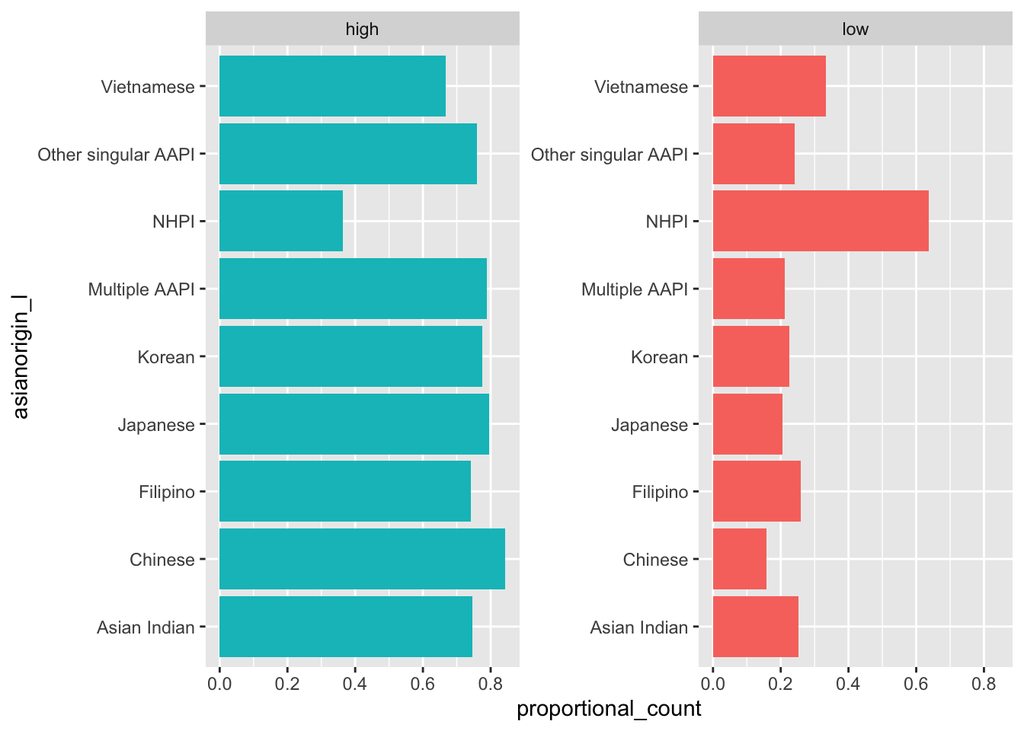

| asianorigin_l | fshigh | fslow | se.fshigh | se.fslow |
| --- | --- | --- | --- | --- |
| Asian Indian | 0.7818370 | 0.2181630 | 0.0516589 | 0.0516589 |
| Chinese | 0.7806802 | 0.2193198 | 0.0367631 | 0.0367631 |
| Filipino | 0.6929215 | 0.3070785 | 0.0574503 | 0.0574503 |
| Japanese | 0.7275141 | 0.2724859 | 0.0700540 | 0.0700540 |
| Korean | 0.7017578 | 0.2982422 | 0.0738831 | 0.0738831 |
| Multiple AAPI | 0.6888369 | 0.3111631 | 0.0758820 | 0.0758820 |
| NHPI | 0.2256546 | 0.7743454 | 0.0844603 | 0.0844603 |
| Other singular AAPI | 0.6669613 | 0.3330387 | 0.0642507 | 0.0642507 |
| Vietnamese | 0.6125550 | 0.3874450 | 0.0900269 | 0.0900269 |

## Age Breakdown for Demographic Group

```
## [[1]]
##
##
## Table: Chinese
##
## |fs   |     18-29|     30-44|     45-59|   60+|
## |:----|---------:|---------:|---------:|-----:|
## |high | 0.8333333| 0.8471338| 0.8181818| 0.875|
## |low  | 0.1666667| 0.1528662| 0.1818182| 0.125|
##
## [[2]]
##
##
## Table: Filipino
##
## |fs   | 18-29|     30-44|     45-59|       60+|
## |:----|-----:|---------:|---------:|---------:|
## |high |   0.6| 0.7115385| 0.7096774| 0.9130435|
## |low  |   0.4| 0.2884615| 0.2903226| 0.0869565|
##
## [[3]]
##
##
## Table: Japanese
##
## |fs   | 18-29| 30-44|     45-59|       60+|
## |:----|-----:|-----:|---------:|---------:|
## |high |     1|   0.8| 0.8285714| 0.7272727|
## |low  |     0|   0.2| 0.1714286| 0.2727273|
##
## [[4]]
##
##
## Table: Asian Indian
##
## |fs   |     18-29|     30-44|     45-59|       60+|
## |:----|---------:|---------:|---------:|---------:|
## |high | 0.6363636| 0.8139535| 0.7619048| 0.5833333|
## |low  | 0.3636364| 0.1860465| 0.2380952| 0.4166667|
##
```

[output cut: 34 more lines]

```
##
## |fs   |     18-29|     30-44|     45-59| 60+|
## |:----|---------:|---------:|---------:|---:|
## |high | 0.6666667| 0.6956522| 0.6666667| 0.6|
## |low  | 0.3333333| 0.3043478| 0.3333333| 0.4|
##
## [[9]]
##
##
## Table: Other singular AAPI
##
## |fs   |     18-29| 30-44|     45-59|       60+|
## |:----|---------:|-----:|---------:|---------:|
## |high | 0.8461538|  0.72| 0.8055556| 0.6666667|
## |low  | 0.1538462|  0.28| 0.1944444| 0.3333333|
```

## Country of Origin Breakdown

| fs | Don’t know/Skipped/Refused | In the US | Outside the US |
| --- | --- | --- | --- |
| high | 0.5 | 0.7818182 | 0.773622 |
| low | 0.5 | 0.2181818 | 0.226378 |

## Nutrition Security

Calculating low nutrition security for those who answered “somewhat hard”, “hard”, or “very hard” to question 1 in the nutrition screener.

| ns | n |
| --- | --- |
| high | 879 |
| low | 222 |
| NA | 14 |

## State Breakdown

Calculating low nutrition security for those who answered “somewhat hard”, “hard”, or “very hard” to question 1 in the nutrition screener.

| fs | AR | CA | DE | IL | MA | NC | NJ | NM | NY | OR | WA |
| --- | --- | --- | --- | --- | --- | --- | --- | --- | --- | --- | --- |
| high | 0.5 | 0.78511 | 1 | 0.8163265 | 0.9565217 | 0.7857143 | 0.9166667 | 0.6666667 | 0.7647059 | 0.8461538 | 0.8181818 |
| low | 0.5 | 0.21489 | 0 | 0.1836735 | 0.0434783 | 0.2142857 | 0.0833333 | 0.3333333 | 0.2352941 | 0.1538462 | 0.1818182 |

| ns | AR | CA | DE | IL | MA | NC | NJ | NM | NY | OR | WA |
| --- | --- | --- | --- | --- | --- | --- | --- | --- | --- | --- | --- |
| high | 1 | 0.8037225 | 0.6666667 | 0.8367347 | 0.9130435 | 0.8571429 | 0.7916667 | 0.6666667 | 0.7647059 | 0.6923077 | 0.8636364 |
| low | 0 | 0.1810491 | 0.3333333 | 0.1632653 | 0.0869565 | 0.0714286 | 0.2083333 | 0.3333333 | 0.2352941 | 0.3076923 | 0.1363636 |
| NA | 0 | 0.0152284 | 0.0000000 | 0.0000000 | 0.0000000 | 0.0714286 | 0.0000000 | 0.0000000 | 0.0000000 | 0.0000000 | 0.0000000 |